# Titanic_Extraction and Data Analysis

```python
import numpy as np
import pandas as pd
import matplotlib.pyplot as plt
import seaborn as sns

from matplotlib import style
style.use('ggplot')

import warnings
warnings.filterwarnings('ignore')
```

### # Extraction of Data

```python
titanic = pd.read_csv('train.csv')
titanic.head(10)
```

|  | PassengerId | Survived | Pclass | Name | Sex | Age | SibSp | Parch | Ticket | Fare | Cabin | Embarked |
| --- | --- | --- | --- | --- | --- | --- | --- | --- | --- | --- | --- | --- |
| 0 | 1 | 0 | 3 | Braund, Mr. Owen Harris | male | 22.0 | 1 | 0 | A/5 21171 | 7.2500 | NaN | S |
| 1 | 2 | 1 | 1 | Cumings, Mrs. John Bradley (Florence Briggs Th... | female | 38.0 | 1 | 0 | PC 17599 | 71.2833 | C85 | C |
| 2 | 3 | 1 | 3 | Heikkinen, Miss. Laina | female | 26.0 | 0 | 0 | STON/O2. 3101282 | 7.9250 | NaN | S |
| 3 | 4 | 1 | 1 | Futrelle, Mrs. Jacques Heath (Lily May Peel) | female | 35.0 | 1 | 0 | 113803 | 53.1000 | C123 | S |
| 4 | 5 | 0 | 3 | Allen, Mr. William Henry | male | 35.0 | 0 | 0 | 373450 | 8.0500 | NaN | S |
| 5 | 6 | 0 | 3 | Moran, Mr. James | male | NaN | 0 | 0 | 330877 | 8.4583 | NaN | Q |
| 6 | 7 | 0 | 1 | McCarthy, Mr. Timothy J | male | 54.0 | 0 | 0 | 17463 | 51.8625 | E46 | S |
| 7 | 8 | 0 | 3 | Palsson, Master. Gosta Leonard | male | 2.0 | 3 | 1 | 349909 | 21.0750 | NaN | S |
| 8 | 9 | 1 | 3 | Johnson, Mrs. Oscar W (Elisabeth Vilhelmina Berg) | female | 27.0 | 0 | 2 | 347742 | 11.1333 | NaN | S |
| 9 | 10 | 1 | 2 | Nasser, Mrs. Nicholas (Adele Achem) | female | 14.0 | 1 | 0 | 237736 | 30.0708 | NaN | C |

### # Data Cleaning

```python
titanic.info()
```

```
<class 'pandas.core.frame.DataFrame'>
RangeIndex: 891 entries, 0 to 890
Data columns (total 12 columns):
 #   Column       Non-Null Count  Dtype
---  ------       --------------  -----
 0   PassengerId  891 non-null    int64
 1   Survived     891 non-null    int64
 2   Pclass       891 non-null    int64
 3   Name         891 non-null    object
 4   Sex          891 non-null    object
 5   Age          714 non-null    float64
 6   SibSp        891 non-null    int64
 7   Parch        891 non-null    int64
 8   Ticket       891 non-null    object
 9   Fare         891 non-null    float64
 10  Cabin        204 non-null    object
 11  Embarked     889 non-null    object
dtypes: float64(2), int64(5), object(5)
memory usage: 83.7+ KB
```

#### Checking for unique values

```python
print('Survived   :',titanic.Survived.unique())
print('Pclass   :',titanic.Pclass.unique())
print('Gender   :',titanic.Sex.unique())
print('Embarked   :',titanic.Embarked.dropna().unique())
```

```
Survived   : [0 1]
Pclass   : [3 1 2]
Gender   : ['male' 'female']
Embarked   : ['S' 'C' 'Q']
```

```python
titanic.duplicated().sum()                  # no duplicate values
```

```
0
```

```python
titanic.isnull().sum()
```

```
PassengerId      0
Survived         0
Pclass           0
Name             0
Sex              0
Age            177
SibSp            0
Parch            0
Ticket           0
Fare             0
Cabin          687
Embarked         2
dtype: int64
```

#### 1. Numerical column

```python
mean_age = titanic.Age.mean()
titanic.Age.replace(np.nan,mean_age,inplace = True)
```

```python
titanic.Age.isnull().sum()
```

```
0
```

#### 2. Categorical column

```python
mode_emb = titanic.Embarked.dropna().mode()[0]
```

```python
titanic.Embarked.replace(np.nan,mode_emb,inplace = True)
```

```python
titanic.Embarked.isnull().sum()
```

```
0
```

#### 3. If number of missing values is large wrt to the number of rows then we can drop the column

```python
titanic.drop('Cabin', axis = 1, inplace = True)
```

```python
titanic.head()
```

|  | PassengerId | Survived | Pclass | Name | Sex | Age | SibSp | Parch | Ticket | Fare | Embarked |
| --- | --- | --- | --- | --- | --- | --- | --- | --- | --- | --- | --- |
| 0 | 1 | 0 | 3 | Braund, Mr. Owen Harris | male | 22.0 | 1 | 0 | A/5 21171 | 7.2500 | S |
| 1 | 2 | 1 | 1 | Cumings, Mrs. John Bradley (Florence Briggs Th... | female | 38.0 | 1 | 0 | PC 17599 | 71.2833 | C |
| 2 | 3 | 1 | 3 | Heikkinen, Miss. Laina | female | 26.0 | 0 | 0 | STON/O2. 3101282 | 7.9250 | S |
| 3 | 4 | 1 | 1 | Futrelle, Mrs. Jacques Heath (Lily May Peel) | female | 35.0 | 1 | 0 | 113803 | 53.1000 | S |
| 4 | 5 | 0 | 3 | Allen, Mr. William Henry | male | 35.0 | 0 | 0 | 373450 | 8.0500 | S |

#### 4. Combining two columns

```python
titanic['family_members'] = titanic.SibSp + titanic.Parch
```

```python
titanic.head()
```

[output not shown]

#### 5. Dropping Extra unwanted columns

```python
titanic.drop(['SibSp','Parch'],axis = 1,inplace = True)
```

```python
titanic.head()
```

[output not shown]

# Data Analysis

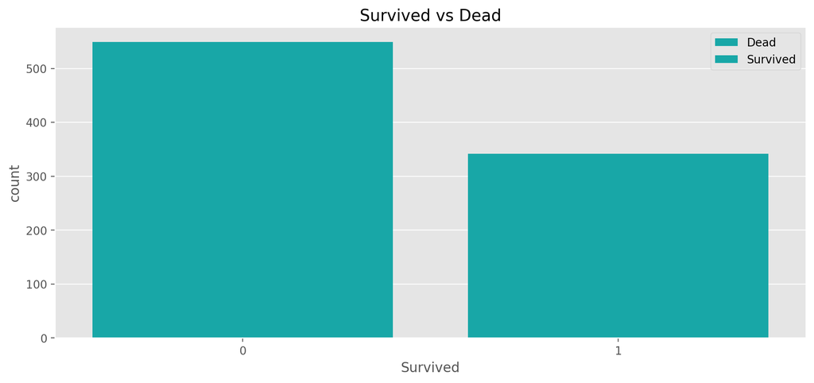

```python
plt.figure(figsize = (12,5),dpi = 200)
sns.countplot(x = 'Survived',label = ['Dead','Survived'],data = titanic,color = 'c')
plt.title('Survived vs Dead')
```

```python
titanic.Survived.value_counts()
```

```
Survived
0    549
1    342
Name: count, dtype: int64
```

```python
Survival = titanic.Survived.value_counts(normalize = True)
print('Dead       :',round(Survival[0]*100),'%')
print('Survived   :',round(Survival[1]*100),'%')
```

```
Dead       : 62 %
Survived   : 38 %
```

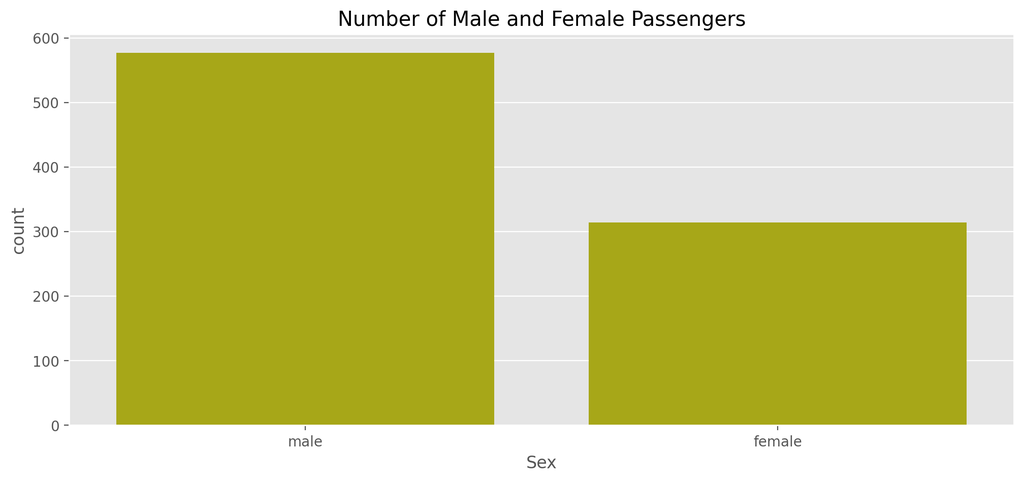

```python
plt.figure(figsize = (12,5),dpi = 200)
sns.countplot(x = 'Sex',data = titanic, color = 'y')
plt.title('Number of Male and Female Passengers')
```

```python
gender = titanic.Sex.value_counts()
gender
```

```
Sex
male      577
female    314
Name: count, dtype: int64
```

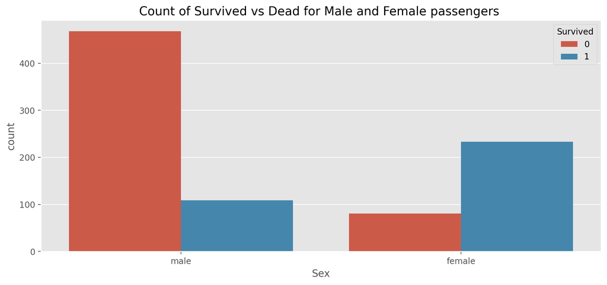

```python
plt.figure(figsize = (12,5),dpi = 200)
sns.countplot(x = 'Sex',hue = 'Survived',data = titanic )
plt.title('Count of Survived vs Dead for Male and Female passengers ')
```

#### Observation: Female passengers had a higher rate of survival than Male passengers

```python
gender_svl_rate= titanic.groupby('Sex').Survived.value_counts(normalize = True).sort_index()
gender_svl_rate * 100
```

```
Sex     Survived
female  0           25.796178
        1           74.203822
male    0           81.109185
        1           18.890815
Name: proportion, dtype: float64
```

```python
print('Female Survivors :',round(gender_svl_rate['female'][1]*100,2),'%')
print('Females Dead :',round(gender_svl_rate['female'][0]*100,2),'%')
print('Male Survivors :',round(gender_svl_rate['male'][1]*100,2),'%')
print('Males Dead:',round(gender_svl_rate['male'][0]*100,2),'%')
```

```
Female Survivors : 74.2 %
Females Dead : 25.8 %
Male Survivors : 18.89 %
Males Dead: 81.11 %
```

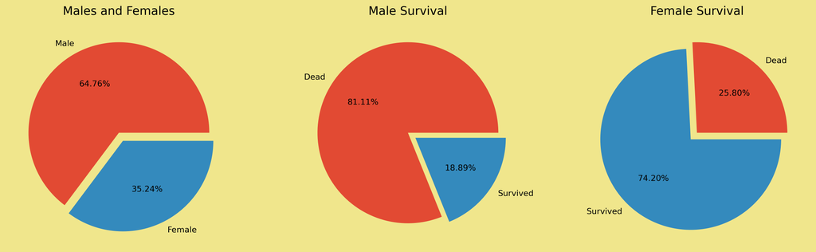

```python
# Creating Pie charts
gender = titanic.Sex.value_counts()
gender_label = ['Male','Female']

gender_svl = titanic.groupby('Sex').Survived.value_counts().sort_index()
male_svl = titanic.groupby('Sex').Survived.value_counts().sort_index()['male']
female_svl = titanic.groupby('Sex').Survived.value_counts().sort_index()['female']

svl_labels = ['Dead','Survived']

plt.figure(figsize = (18,5),dpi = 300, facecolor = 'khaki')

plt.subplot(1,3,1)
plt.pie(gender,labels = gender_label,autopct = '%1.2f%%',explode = [0,0.1])
plt.title('Males and Females')

plt.subplot(1,3,2)
plt.pie(male_svl,labels = svl_labels,autopct = '%1.2f%%',explode = [0,0.1])
plt.title('Male Survival')

plt.subplot(1,3,3)
plt.pie(female_svl,labels = svl_labels,autopct = '%1.2f%%',explode = [0,0.1])
plt.title('Female Survival')

plt.show()
```

#### Observation: Of the total passengers 64.76% were male and 35.24% were female. However The rate of survival of female passenger was higher at 74.20% then that of male passenger at 18.89%.

```python
pclass_svl= titanic.groupby('Pclass').Survived.value_counts().sort_index()
pclass_svl
```

```
Pclass  Survived
1       0            80
        1           136
2       0            97
        1            87
3       0           372
        1           119
Name: count, dtype: int64
```

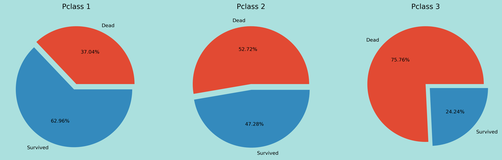

```python
plt.figure(figsize = (18,6),dpi = 300, facecolor = '#abe0de')

plt.subplot(1,3,1)
plt.pie(pclass_svl[1],labels = ['Dead','Survived'],autopct = '%1.2f%%',explode = [0,0.1])
plt.title('Pclass 1')

plt.subplot(1,3,2)
plt.pie(pclass_svl[2],labels = ['Dead','Survived'],autopct = '%1.2f%%',explode = [0,0.1])
plt.title('Pclass 2')

plt.subplot(1,3,3)
plt.pie(pclass_svl[3],labels = ['Dead','Survived'],autopct = '%1.2f%%',explode = [0,0.1])
plt.title('Pclass 3')

plt.show()
```

#### The Rate of Survival of passengers from Class 1 was much higher than that of passengers from class 2 and 3.

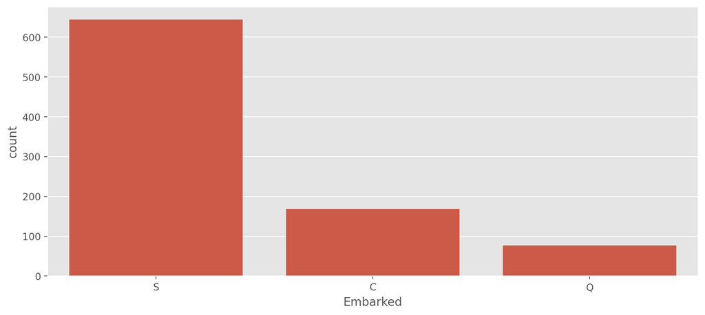

```python
# Embarked
plt.figure(figsize = (12,5),dpi = 200)
sns.countplot(x = 'Embarked',data=titanic)
```

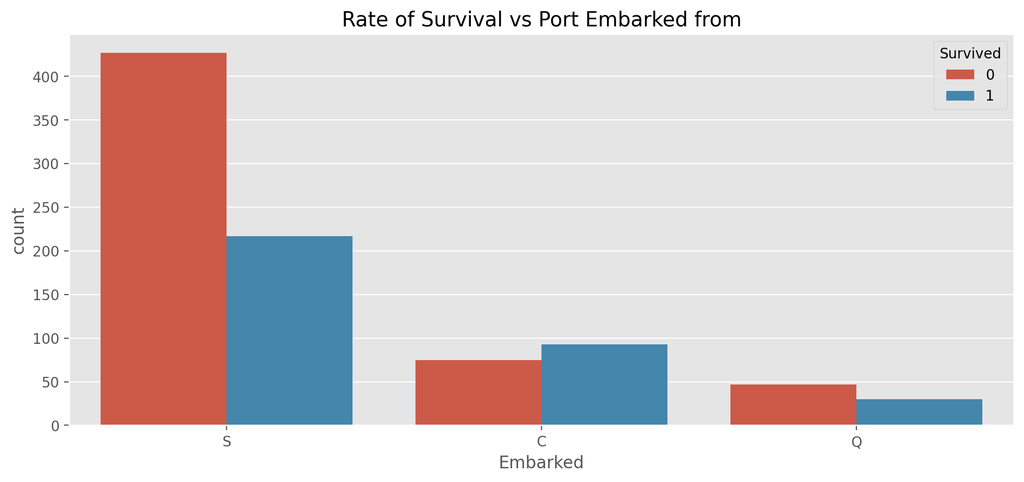

```python
# Embarked
plt.figure(figsize = (12,5),dpi = 200)
sns.countplot(x = 'Embarked',hue = 'Survived',data=titanic)
plt.title('Rate of Survival vs Port Embarked from')
```

#### Observation: Passenger who boarded from port C had a much higher rate of survival than that from port S and Q

```python
titanic.Embarked.value_counts()
```

```
Embarked
S    644
C    168
Q     77
Name: count, dtype: int64
```

```python
embarked_svl = titanic.groupby('Embarked').Survived.value_counts().sort_index()
embarked_svl
```

```
Embarked  Survived
C         0            75
          1            93
Q         0            47
          1            30
S         0           427
          1           217
Name: count, dtype: int64
```

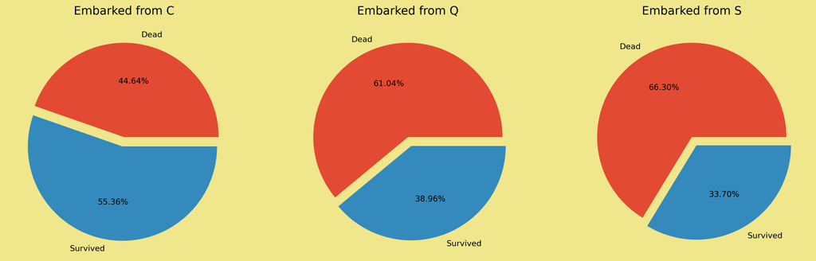

```python
plt.figure(figsize = (18,6),dpi = 300, facecolor = 'khaki')

plt.subplot(1,3,1)
plt.pie(embarked_svl['C'],labels = ['Dead','Survived'],autopct = '%1.2f%%',explode = [0,0.1])
plt.title('Embarked from C')

plt.subplot(1,3,2)
plt.pie(embarked_svl['Q'],labels = ['Dead','Survived'],autopct = '%1.2f%%',explode = [0,0.1])
plt.title('Embarked from Q')

plt.subplot(1,3,3)
plt.pie(embarked_svl['S'],labels = ['Dead','Survived'],autopct = '%1.2f%%',explode = [0,0.1])
plt.title('Embarked from S')

plt.show()
```

```python
titanic.family_members.unique()
```

```
array([ 1,  0,  4,  2,  6,  5,  3,  7, 10], dtype=int64)
```

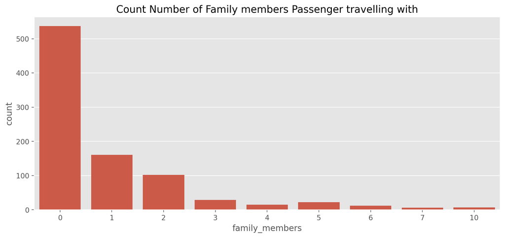

```python
plt.figure(figsize = (12,5),dpi = 200)
sns.countplot(x = 'family_members',data = titanic)
plt.title('Count Number of Family members Passenger travelling with')
```

```python
titanic['family_members'].value_counts()
```

```
family_members
0     537
1     161
2     102
3      29
5      22
4      15
6      12
10      7
7       6
Name: count, dtype: int64
```

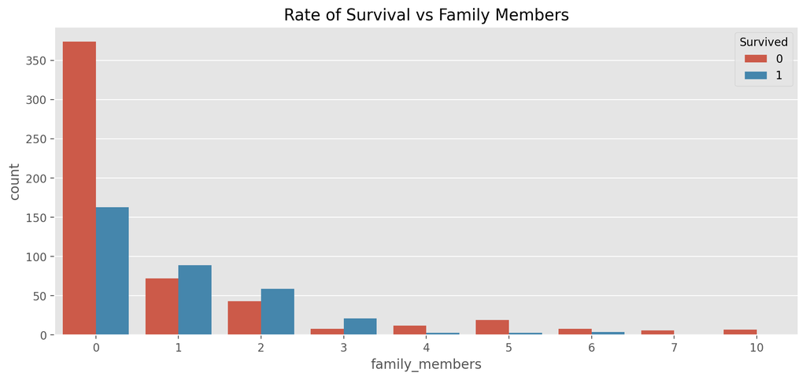

```python
plt.figure(figsize = (12,5),dpi = 200)
sns.countplot(x = 'family_members', hue = 'Survived',data = titanic)
plt.title('Rate of Survival vs Family Members')
```

### Observation: The Rate of Survival of passengers with 1,2 and 3 family members was much higher than that of passengers travelling with 0 and more than 4 family members.

```python
#Find the survival rate of passengers who were traveling with 0 family mambers
fm_svl_ttl = titanic.family_members.value_counts().sort_index()
print(fm_svl_ttl[0])
```

```
537
```

```python
fm_svl = titanic.groupby('family_members').Survived.value_counts().sort_index()
fm_svl
```

```
family_members  Survived
0               0           374
                1           163
1               0            72
                1            89
2               0            43
                1            59
3               0             8
                1            21
4               0            12
                1             3
5               0            19
                1             3
6               0             8
                1             4
7               0             6
10              0             7
Name: count, dtype: int64
```

```python
print('Survival rate of passengers travelling with 0 family members is :',round((fm_svl[0][1]/fm_svl_ttl[0])*100,2),'%')
```

```
Survival rate of passengers travelling with 0 family members is : 30.35 %
```

```python
# Survival of passengers travelling with 1,2, 3 family members

fm_svl_123 = fm_svl[1][1] + fm_svl[2][1] + fm_svl[3][1]
fm_123 = fm_svl_ttl[1] + fm_svl_ttl[2]+fm_svl_ttl[3]
print('Survival rate of passengers travelling with 1,2,3 family members is :',round((fm_svl_123/fm_123)*100,2),'%')
```

```
Survival rate of passengers travelling with 1,2,3 family members is : 57.88 %
```

```python
# Survival of passengers travelling with 4 or more family members passengers

print('Survival rate of passengers travelling with 4 or more than 4 family members is :',round(titanic[titanic.family_members >= 4].Survived.value_counts(normalize = True)[1]*100,2),'%')
```

```
Survival rate of passengers travelling with 4 or more than 4 family members is : 16.13 %
```

```python
titanic[(titanic.Fare>=500)]
```

[output not shown]

```python
per_fare = len(titanic[(titanic.Fare>=200) & (titanic.Fare < 300)])
per_fare
```

```
17
```

```python
total_fare = per_fare/len(titanic) * 100
total_fare
```

```
1.9079685746352413
```

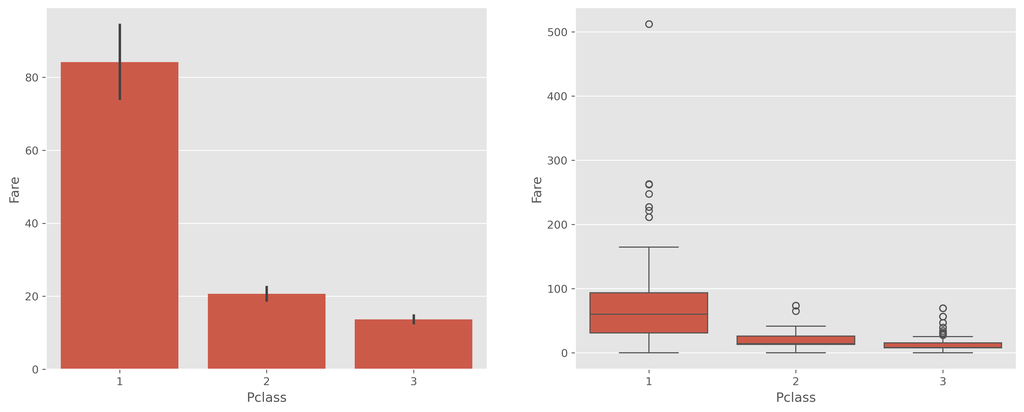

```python
# Fare and Passnger Class
plt.figure(figsize = (16,6),dpi = 300)

plt.subplot(1,2,1)
sns.barplot(x = 'Pclass',y = 'Fare',data = titanic)

plt.subplot(1,2,2)
sns.boxplot(x = 'Pclass',y = 'Fare',data = titanic)
```

### Observation: The fare for Class 1 is hgher than that of class 2 and 3

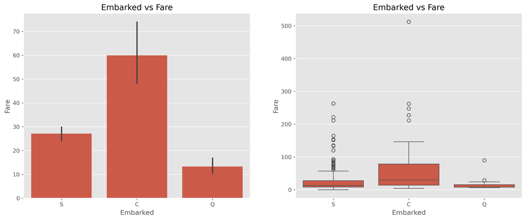

```python
# Fare and Embarked
plt.figure(figsize = (16,6),dpi = 300)

plt.subplot(1,2,1)
sns.barplot(x = 'Embarked',y = 'Fare',data = titanic)
plt.title('Embarked vs Fare')

plt.subplot(1,2,2)
sns.boxplot(x = 'Embarked',y = 'Fare',data = titanic)
plt.title('Embarked vs Fare')
```

### Observation: Passengers from port C paid a higher fare as compared to passengers from port S and Q

```python
# From which port the ratio of travellers in passenger class 1 was the highest?
```

```python
titanic.groupby('Embarked').Pclass.value_counts(normalize = True)
```

```
Embarked  Pclass
C         1         0.505952
          3         0.392857
          2         0.101190
Q         3         0.935065
          2         0.038961
          1         0.025974
S         3         0.548137
          2         0.254658
          1         0.197205
Name: proportion, dtype: float64
```

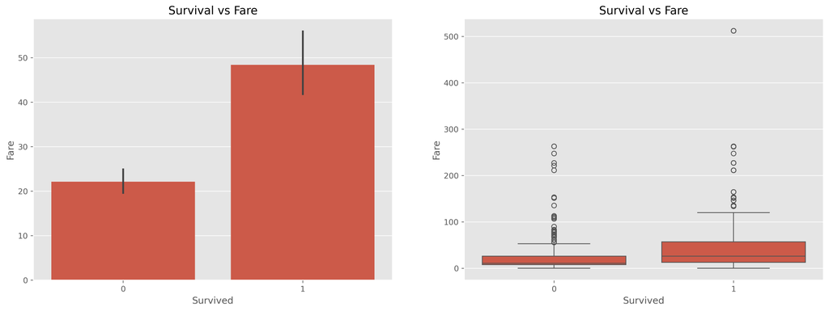

```python
# Fare and Survived
plt.figure(figsize = (18,6),dpi = 300)

plt.subplot(1,2,1)
sns.barplot(x = 'Survived',y = 'Fare',data = titanic)
plt.title('Survival vs Fare')

plt.subplot(1,2,2)
sns.boxplot(x = 'Survived',y  = 'Fare',data = titanic)
plt.title('Survival vs Fare')
```

#### Observation: Passengers who paid higher fare had a higher rate of Survival

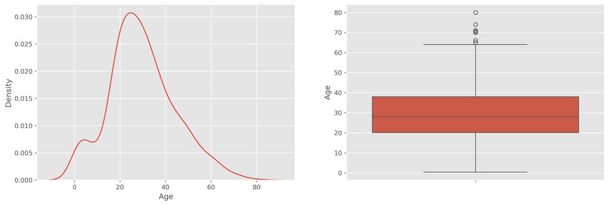

```python
# Age
plt.figure(figsize = (16,5),dpi = 300)
plt.subplot(1,2,1)
sns.distplot(titanic.Age,hist = False)
plt.subplot(1,2,2)
sns.boxplot(y = titanic.Age,data = titanic)
```

```python
# What percentage of travellers have age between 20 to 40?
a = len(titanic[(titanic.Age >= 20)*(titanic.Age<=40)])
a/len(titanic) * 100
```

```
44.89337822671156
```

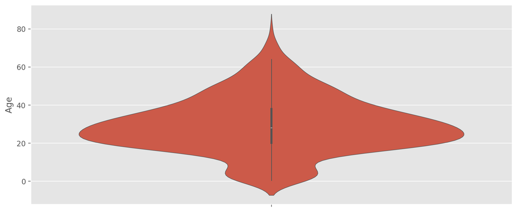

```python
plt.figure(figsize = (12,5),dpi = 200)
sns.violinplot(y = 'Age',data = titanic)
```

#### Observation: Maximum number of passenger travelling were in the age group of 20 to 40

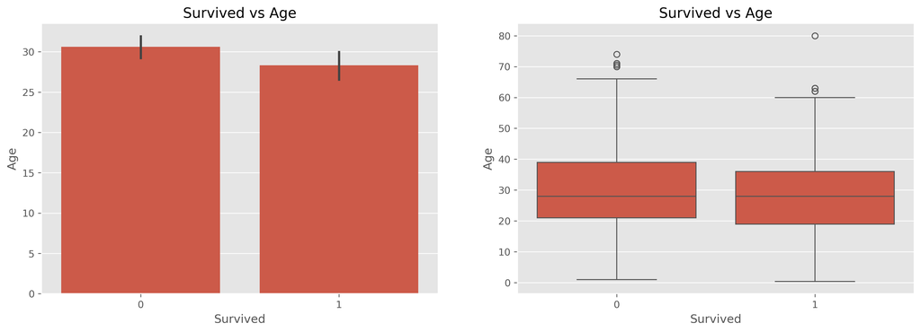

```python
# Age and survived
plt.figure(figsize = (16,5),dpi = 300)
plt.subplot(1,2,1)
sns.barplot(x = 'Survived',y = 'Age',data = titanic)
plt.title('Survived vs Age')
plt.subplot(1,2,2)
sns.boxplot(x = 'Survived',y = 'Age',data = titanic)
plt.title('Survived vs Age')
```

#### Observation: As apparent from the plots Age has no effect upon the Survival

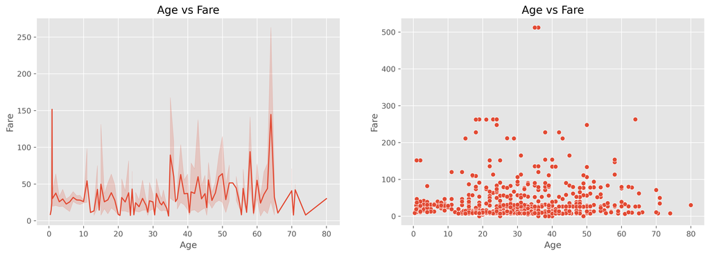

```python
# Age and Fare

plt.figure(figsize = (16,5),dpi = 300)
plt.subplot(1,2,1)
sns.lineplot(x = 'Age',y = 'Fare',data = titanic)
plt.title('Age vs Fare')

plt.subplot(1,2,2)
sns.scatterplot(x = 'Age',y = 'Fare',data = titanic)
plt.title('Age vs Fare')
```

#### As can be seen the trend is flat hence there is no effect of Age upon the Fare of the ticket.

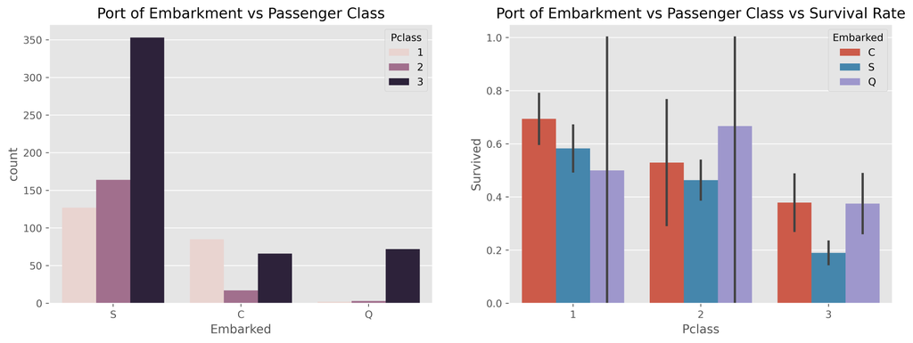

```python
plt.figure(figsize = (15,5),dpi = 500)
plt.subplot(1,2,1)
sns.countplot(x = 'Embarked',hue = 'Pclass',data = titanic)
plt.title('Port of Embarkment vs Passenger Class')

plt.subplot(1,2,2)
sns.barplot(x = 'Pclass',y = 'Survived',hue = 'Embarked',data = titanic)
plt.title('Port of Embarkment vs Passenger Class vs Survival Rate')
```

```python
a = round(titanic.groupby(titanic.Embarked).Survived.value_counts(normalize = True)*100,2).sort_index()
b= titanic.Embarked.value_counts().sort_index()
print(a,'\n')
print(b)
```

```
Embarked  Survived
C         0           44.64
          1           55.36
Q         0           61.04
          1           38.96
S         0           66.30
          1           33.70
Name: proportion, dtype: float64

Embarked
C    168
Q     77
S    644
Name: count, dtype: int64
```

#### Conclusion:

```
We conclude from the above analysis that Female passengers had a higher survival rate then Male passenger. Also, Passengers from Class 1 and passengers travelling with 1, 2 or 3 family members had a higher Ratio of Survival than those travelling in class 2 and 3 or passengers travelling alone or with 4 or higher number of family members. As the fare for class 1 was higher then that of class 2 and 3, it can also be said that passengers who paid higher Fare had a higher Rate of Survival then others.
```